# Lab 04 - Closeness/Betweeness Centrality - SOLUTIONS

CRJ 507 Social Network Analysis

# Instructions

The purpose of this lab is to familiarize yourself with calculating closeness centrality and betweeness centrality scores as well as centralization scores for undirected and directed networks in *R*. Please review the [Closeness Centrality](https://jacobtnyoung.github.io/sna-textbook/ch-06-centrality-closeness.html) and the [Betweeness Centrality](https://jacobtnyoung.github.io/sna-textbook/ch-07-centrality-betweenness.html) chapters of the [SNA Textbook](https://jacobtnyoung.github.io/sna-textbook/index.html) as well as Tutorial 6 - Closeness Centrality and Centralization in R and Tutorial 7 - Betweenness Centrality and Centralization in R, prior to beginning this lab.

For this part of the lab you will again use data from [Thomas Grund and James Densley’s study](https://journals.sagepub.com/doi/full/10.1177/1043986214553377) of ties among members of an inner-city gang in London, England. The network is undirected, binary ties collected from anonymized arrests data. We will refer to this network as the `LondonGangNet`.

For the `LondonGangNet` network, do the following:

1. Calculate the degree, closeness, and betweenness centrality scores for each actor.
2. Calculate the standardized degree, closeness, and betweenness centrality scores for each actor.
3. Calculate the mean degree, closeness, and betweenness centrality score.
4. Compare the differences for the three mean centrality scores for each measure of centrality.
5. Calculate the graph centralization for degree, closeness, and betweenness centrality scores.
6. Discuss the graph centralization score for closeness centrality.
7. Discuss the graph centralization score for betweenness centrality.
8. Compare the differences for the three graph centralization scores for each measure of centrality.
9. Plot the network three times using the `gplot()` function where each plot sizes the nodes by the centrality score (i.e. a plot for degree centrality, a plot for closeness centrality, and a plot for betweenness centrality).

## Part II: Working with a Directed Network

For this part of the lab you will again use data from [Mangia Natarajan’s study](https://link.springer.com/article/10.1007/s10940-006-9007-x) of a large cocaine trafficking organization in New York City. The network is directed, binary ties of communication between individuals collected from police wiretaps of 151 telephone conversations. The raw data are available [here](https://sites.google.com/site/ucinetsoftware/datasets/covert-networks/cocainedealingnatarajan). We will refer to this network as the `CocaineDealingNet`.

For the `CocaineDealingNet` network, do the following:

1. Calculate the indegree, outdegree, closeness, and betweenness centrality scores for each actor.
2. Calculate the standardized indegree, outdegree, closeness, and betweenness centrality scores for each actor.
3. Calculate the mean indegree, outdegree, closeness, and betweenness centrality score.
4. Compare the differences for the four mean centrality scores for each measure of centrality.
5. Calculate the graph centralization for indegree, outdegree, closeness, and betweenness centrality scores.
6. Discuss the graph centralization score for closeness centrality.
7. Discuss the graph centralization score for betweenness centrality.
8. Compare the differences for the four graph centralization scores for each measure of centrality.
9. Plot the network four times using the `gplot()` function where each plot sizes the nodes by the centrality score (i.e. a plot for indegree centrality, a plot for outdegree centrality, a plot for closeness centrality, and a plot for betweenness centrality).

## Part III:

In lab 01 you created two networks and in lab 02 you imported, created a object of class network, and plotted the networks. In lab 03 you examined degree centrality for your networks. I would like you to continue working with those networks for this part of the lab.

Pick **one** of your networks and do the following:

- If the network is *undirected*, repeat the steps in Part I.
- If the network is *directed*, repeat the steps in Part II.

# **Solutions**

## Setup

```r
# clear the workspace
rm( list = ls() )
```

## Part I

First, let’s read in the `LondonGangNet` network. This is stored as an .rds document in the data folder on the [SNA Textbook](https://github.com/jacobtnyoung/sna-textbook/tree/main/data) site. We will use the `readRDS()` function, with the [file path](https://github.com/jacobtnyoung/sna-textbook/raw/main/data/data-london-gang-net.rds), to load the file. Since we are calling a url, we need to use the `url()` function as well.

Finally, we need to make sure the `sna` and `network` packages are loaded, using `library()`, so that R recognizes the `LondonGangNet` object as one of class `network`.

```r
# load the libraries we need
library( sna )
library( network )

# define the path location for the file
loc <- "https://github.com/jacobtnyoung/sna-textbook/raw/main/data/data-london-gang-net.rds"
LondonGangNet <- readRDS( url(loc ) )

# look at the network
LondonGangNet
```

```
##  Network attributes:
##   vertices = 54
##   directed = FALSE
##   hyper = FALSE
##   loops = FALSE
##   multiple = FALSE
##   bipartite = FALSE
##   total edges= 315
##     missing edges= 0
##     non-missing edges= 315
##
##  Vertex attribute names:
##     Age Arrests Birthplace Convictions Music Prison Ranking Residence vertex.names
##
## No edge attributes
```

#### 1. Calculate the degree, closeness, and betweenness centrality scores for each actor.

```r
# use the degree() function in the sna package
deg.gang <- degree(
  LondonGangNet,
  gmode = "graph",
  cmode = "degree"
  )
```

Now let’s calculate the closeness and betweenness scores. Recall that the `closeness()` function reports the standardized closeness centrality by default. If we want the unstandardized closeness, we can just divide the result returned by `closeness()` by *g-1*.

```r
# set the number of nodes in the network
g <- dim( as.matrix( LondonGangNet ) )[1]

# raw closeness centrality
close.gang <- closeness( LondonGangNet, gmode="graph" ) / ( g - 1 )

# raw betweenness centrality
btwn.gang <- betweenness(
  LondonGangNet,
  gmode="graph"
  )
```

#### 2. Calculate the standardized degree, closeness, and betweenness centrality scores for each actor.

```r
# standardized score is deg / g-1 where g is the number of nodes
s.deg.gang <- deg.gang / ( g - 1 )

# standardized closeness is the score reported by default
s.close.gang <- closeness( LondonGangNet, gmode="graph" )

# standardized betweenness is the betweenness / ( ( ( g-1 ) * ( g-2 ) ) / 2 )
s.btwn.gang <- btwn.gang / ( ( ( g-1 ) * ( g-2 ) ) / 2 )
```

#### 3. Calculate the mean degree, closeness, and betweenness centrality score.

```r
# use the mean() function to calculate the means
mean.deg.gang   <- mean( deg.gang )
mean.close.gang <- mean( close.gang )
mean.btwn.gang  <- mean( btwn.gang )

# create a table that is easy to read
cent.tab <- data.frame(
  deg = round( mean.deg.gang, 2 ),
  close = round( mean.close.gang, 2 ),
  between = round( mean.btwn.gang, 2 )
  )

# print the table
cent.tab
```

| deg | close | between |
| --- | --- | --- |
| 11.67 | 0.01 | 27.93 |

#### 5. Calculate the graph centralization for degree, closeness, and betweenness centrality.

```r
dcent.gang <- centralization( LondonGangNet, degree, mode="graph", cmode="degree" )
ccent.gang <- centralization( LondonGangNet, closeness, mode="graph" )
bcent.gang <- centralization( LondonGangNet, betweenness, mode="graph" )

# create a table that is easy to read
centralization.tab <- data.frame(
  deg = round( dcent.gang, 2 ),
  close = round( ccent.gang, 2 ),
  between = round( bcent.gang, 2 )
  )

# print the table
centralization.tab
```

| deg | close | between |
| --- | --- | --- |
| 0.26 | 0.31 | 0.09 |

#### 6. Discuss the graph centralization score for closeness centrality.

The *closeness* centralization score is somewhat close to zero, at 0.31 meaning that the ties do not differ substantially in terms of their scores.

#### 7. Discuss the graph centralization score for betweenness centrality.

The *betweenness* centralization score is very close to zero, at 0.09 meaning that the ties do not differ substantially in terms of their scores.

#### 8. Compare the differences for the three graph centralization scores for each measure of centrality.

As seen in the table, the *degree* and *closeness* centralization scores show more inequality, relative to the betweenness centralization score.

#### 9. Plot the network three times using the `gplot()` function where each plot sizes the nodes by the centrality score (i.e. a plot for degree centrality, a plot for closeness centrality, and a plot for betweenness centrality).

As we saw in the closeness centrality tutorial, we can use a `for` loop to build a series of plots. Let’s do the same here. We will also use the `rescale()` function from the betweenness centrality tutorial.

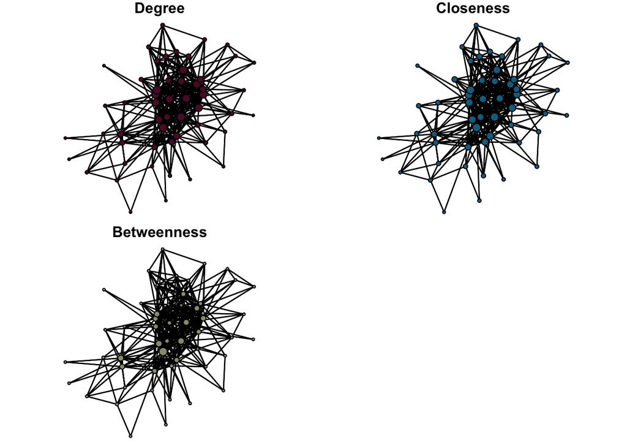

```r
# create the rescale function
rescale <- function( nchar, low, high ){
  min_d <- min( nchar )
  max_d <- max( nchar )
  rscl  <- ( ( high - low )*( nchar - min_d ) ) / ( max_d - min_d ) + low
  rscl
}

# create the inputs for the loop
titles  <- c( "Degree", "Closeness", "Betweenness")
cols    <- c( "#5c1233", "#0c7091", "#949c7b" )
v.sizes <- cbind( deg.gang, close.gang, btwn.gang )

# change the margins using the mar= argument
# change the number of plots using the mfrow= argument
par(
  mfrow=c( 2,2 ),
  mar=c( 0.1, 0.5, 1, 0.1 )
  )

for( i in 1:3 ){

  # set the seed
  set.seed( 507 )

  # render the plot
  gplot(
  LondonGangNet,
  gmode = "graph",
  vertex.col = cols[i],
  vertex.cex = rescale( v.sizes[,i], 0.5, 1.5 ),
  main = titles[i]
  )

}
```

#### 10. Examine the plots. Describe how the differences you noted between the centrality measures above are seen in the plot.

The plots show that all three measures describe similar aspects of the network. Mainly, that there are core nodes (larger) and peripheral nodes (smaller). And, that there is much overlap in the network.

## Part II

First, let’s read in the `CocaineDealingNet` network. This is stored as an .rds document in the data folder on the [SNA Textbook](https://github.com/jacobtnyoung/sna-textbook/tree/main/data) site. We will use the `readRDS()` function, with the [file path](https://github.com/jacobtnyoung/sna-textbook/raw/main/data/data-cocaine-dealing-net.rds), to load the file. Since we are calling a url, we need to use the `url()` function as well.

Above, we needed to make sure the `sna` and `network` packages were loaded, but we loaded them above so we do not need to repeat the step here.

```r
# define the path location for the file
loc2 <- "https://github.com/jacobtnyoung/sna-textbook/raw/main/data/data-cocaine-dealing-net.rds"
CocaineDealingNet <- readRDS( url(loc2 ) )

# look at the network
CocaineDealingNet
```

```
##  Network attributes:
##   vertices = 28
##   directed = TRUE
##   hyper = FALSE
##   loops = FALSE
##   multiple = FALSE
##   bipartite = FALSE
##   total edges= 40
##     missing edges= 0
##     non-missing edges= 40
##
##  Vertex attribute names:
##     vertex.names
##
## No edge attributes
```

#### 1. Calculate the indegree, outdegree, closeness, and betweenness centrality scores for each actor.

```r
# use the degree() function in the sna package.
ideg.coc <- degree(
  CocaineDealingNet,
  gmode = "digraph", # note the change to a directed graph
  cmode = "indegree" # ask for the indegree
  )

odeg.coc <- degree(
  CocaineDealingNet,
  gmode = "digraph",  # note the change to a directed graph
  cmode = "outdegree" # toggle to return the outdegree
  )
```

Now let’s calculate the closeness and betweenness scores. Again, recall that the `closeness()` function reports the standardized closeness centrality by default. If we want the unstandardized closeness, we can just divide the result returned by `closeness()` by *g*. Note, that since the graph is directed, we divide by *g*, not *g-1*.

```r
# set the number of nodes in the network
g <- dim( as.matrix( CocaineDealingNet ) )[1]

# raw closeness centrality
close.coc <- closeness( CocaineDealingNet, gmode="digraph" ) / g

# raw betweenness centrality
btwn.coc <- betweenness(
  CocaineDealingNet,
  gmode="digraph"
  )
```

#### 2. Calculate the standardized indegree, outdegree, closeness, and betweenness centrality scores for each actor.

```r
# standardized score is deg / g-1 where g is the number of nodes
s.ideg.coc <- ideg.coc / ( g - 1 )
s.odeg.coc <- odeg.coc / ( g - 1 )

# standardized closeness is the score reported by default
s.close.coc <- closeness( CocaineDealingNet, gmode="digraph" )

# standardized betweenness is the betweenness / ( ( ( g-1 ) * ( g-2 ) ) / 2 )
s.btwn.coc <- btwn.coc / ( ( ( g-1 ) * ( g-2 ) ) / 2 )
```

#### 3. Calculate the mean indegree, outdegree, closeness, and betweenness centrality score.

```r
# use the mean() function to calculate the means
mean.ideg.coc  <- mean( ideg.coc )
mean.odeg.coc  <- mean( odeg.coc )
mean.close.coc <- mean( close.coc )
mean.btwn.coc  <- mean( btwn.coc )

# create a table that is easy to read
cent.tab <- data.frame(
  ideg = round( mean.ideg.coc, 2 ),
  odeg = round( mean.odeg.coc, 2 ),
  close = round( mean.close.coc, 2 ),
  between = round( mean.btwn.coc, 2 )
  )

# print the table
cent.tab
```

| ideg | odeg | close | between |
| --- | --- | --- | --- |
| 1.43 | 1.43 | 0 | 0.46 |

#### 4. Compare the differences for the four mean centrality scores for each measure of centrality.

The mean indegree centrality score is 1.43 meaning that the average node receives 1.43 ties. The mean outdegree centrality score is equal, at 1.43. The mean closeness centrality score is 0, meaning that the average node is not close to the other nodes in the network. Finally, the mean betweenness centrality score is 0.46, meaning that the average node sits on 0.46 paths between *i* and *j*.

#### 5. Calculate the graph centralization for indegree, outdegree, closeness, and betweenness centrality.

```r
# calculate the centralization scores
icent.coc <- centralization( CocaineDealingNet, degree,      mode="digraph", cmode="indegree" )
ocent.coc <- centralization( CocaineDealingNet, degree,      mode="digraph", cmode="outdegree" )
ccent.coc <- centralization( CocaineDealingNet, closeness,   mode="digraph" )
bcent.coc <- centralization( CocaineDealingNet, betweenness, mode="digraph" )

# create a table that is easy to read
centralization.tab <- data.frame(
  ideg = round( icent.coc, 2 ),
  odeg = round( ocent.coc, 2 ),
  close = round( ccent.coc, 2 ),
  between = round( bcent.coc, 2 )
  )

# print the table
centralization.tab
```

| ideg | odeg | close | between |
| --- | --- | --- | --- |
| 0.06 | 0.87 | 0.93 | 0.01 |

#### 6. Discuss the graph centralization score for closeness centrality.

The *closeness* centralization score is very close to 1, at 0.93 meaning that a single node has a very large closeness centrality score and the other nodes have very small closeness centrality scores.

#### 7. Discuss the graph centralization score for betweenness centrality.

The *betweenness* centralization score is very close to zero, at 0.01 meaning that the ties do not differ substantially in terms of their scores.

#### 8. Compare the differences for the three graph centralization scores for each measure of centrality.

As seen in the table, the *outdegree* and *closeness* centralization scores show considerable inequality, relative to the *indegree* and *betweenness* centralization score.

#### 9. Plot the network four times using the `gplot()` function where each plot sizes the nodes by the centrality score (i.e. a plot for indegree centrality, a plot for outdegree centrality, a plot for closeness centrality, and a plot for betweenness centrality).

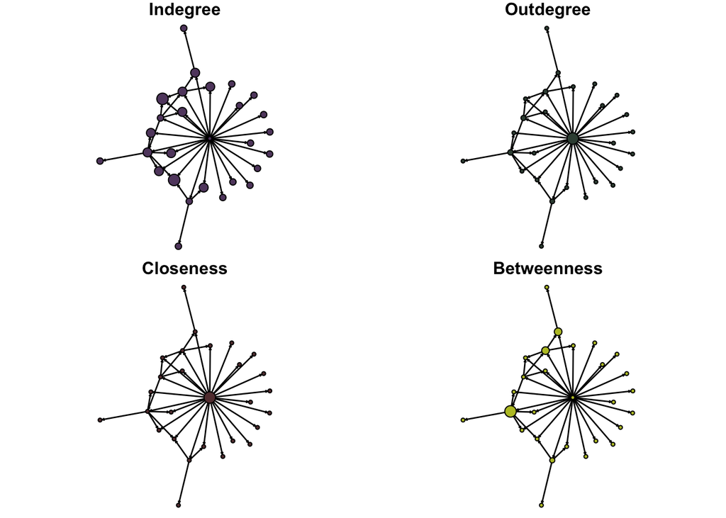

```r
# create the rescale function
rescale <- function( nchar, low, high ){
  min_d <- min( nchar )
  max_d <- max( nchar )
  rscl  <- ( ( high - low )*( nchar - min_d ) ) / ( max_d - min_d ) + low
  rscl
}

# create the inputs for the loop
titles  <- c( "Indegree", "Outdegree", "Closeness", "Betweenness")
cols    <- c( "#61476e", "#394d41", "#633b3d", "#bac22d" )
v.sizes <- cbind( ideg.coc, odeg.coc, close.coc, btwn.coc )

# change the margins using the mar= argument
# change the number of plots using the mfrow= argument
par(
  mfrow=c( 2,2 ),
  mar=c( 0.1, 0.5, 1, 0.1 )
  )

for( i in 1:4 ){

  # set the seed
  set.seed( 507 )

  # render the plot
  gplot(
  CocaineDealingNet,
  gmode = "digraph",
  arrowhead.cex = 0.3,
  vertex.col = cols[i],
  vertex.cex = rescale( v.sizes[,i], 0.5, 1.5 ),
  main = titles[i]
  )

}
```

#### 10. Examine the plots. Describe how the differences you noted between the centrality measures above are seen in the plot.

The plots really help visualize the differences in the centrality measures discussed above. For example, the center node has the highest closeness score because all the other nodes are “far” from each other due to the directional nature of the plot. This is also the case for the outdegree centrality score. The indegree centrality and betweenness centrality scores point to different actors in the network as “central”. This is mainly a consequence of the directional nature of the network.

## Part III:

*Your content here*

##### *Please* report any needed corrections to the [Issues](https://github.com/Watts-College/crj-507-template/issues) page. Thanks!